# R Notebook for Data Science - Excercise 5 R and Julia

# 1. Download Rstudio & R

# 2. Use Rstudio(Posit) to create rmarkdown file

## download package ggplot2

- Installation des Packages kann über das Menü “Tools > Install Paclages…” und Eingabe des Package-Namens mit Klick auf Install, sowie Angabe des Installationsverzeichnisses installiert werden.

## import the data(“iris”)

```r
# use library readr for loading csv data from file.
library(readr)

# load Iris data set from csv file
Iris <- read.csv('./input/Iris.csv')

# output class name
print(class(Iris))
```

```
## [1] "data.frame"
```

```r
# print head of Iris class (column names)
head(Iris)
```

|  | Id | SepalLengthCm | SepalWidthCm | PetalLengthCm | PetalWidthCm | Species |
| --- | --- | --- | --- | --- | --- | --- |
| 1 | 1 | 5.1 | 3.5 | 1.4 | 0.2 | Iris-setosa |
| 2 | 2 | 4.9 | 3.0 | 1.4 | 0.2 | Iris-setosa |
| 3 | 3 | 4.7 | 3.2 | 1.3 | 0.2 | Iris-setosa |
| 4 | 4 | 4.6 | 3.1 | 1.5 | 0.2 | Iris-setosa |
| 5 | 5 | 5.0 | 3.6 | 1.4 | 0.2 | Iris-setosa |
| 6 | 6 | 5.4 | 3.9 | 1.7 | 0.4 | Iris-setosa |

```r
summary(Iris)
```

```
##        Id         SepalLengthCm    SepalWidthCm   PetalLengthCm
##  Min.   :  1.00   Min.   :4.300   Min.   :2.000   Min.   :1.000
##  1st Qu.: 38.25   1st Qu.:5.100   1st Qu.:2.800   1st Qu.:1.600
##  Median : 75.50   Median :5.800   Median :3.000   Median :4.350
##  Mean   : 75.50   Mean   :5.843   Mean   :3.054   Mean   :3.759
##  3rd Qu.:112.75   3rd Qu.:6.400   3rd Qu.:3.300   3rd Qu.:5.100
##  Max.   :150.00   Max.   :7.900   Max.   :4.400   Max.   :6.900
##   PetalWidthCm     Species
##  Min.   :0.100   Length:150
##  1st Qu.:0.300   Class :character
##  Median :1.300   Mode  :character
##  Mean   :1.199
##  3rd Qu.:1.800
##  Max.   :2.500
```

## use the ggplot for all the tasks below

- Verwendung der Libarary “ggplot2” durch Einbindung von library(‘ggplot2’)

```r
library(ggplot2)
```

## make a scatter plot with x-axis: Sepal.Length and y-axis: Sepal.Width, and the species should be shown in different colors

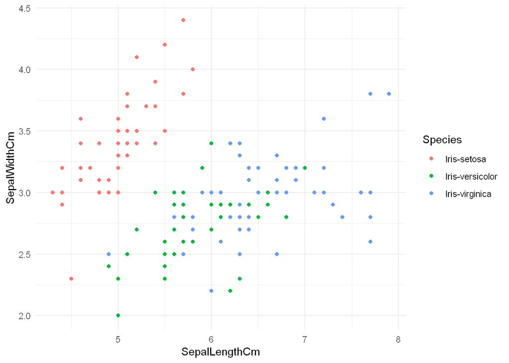

```r
ggplot(data=Iris, aes(x=SepalLengthCm, y=SepalWidthCm, color=Species)) + geom_point() + theme_minimal()
```

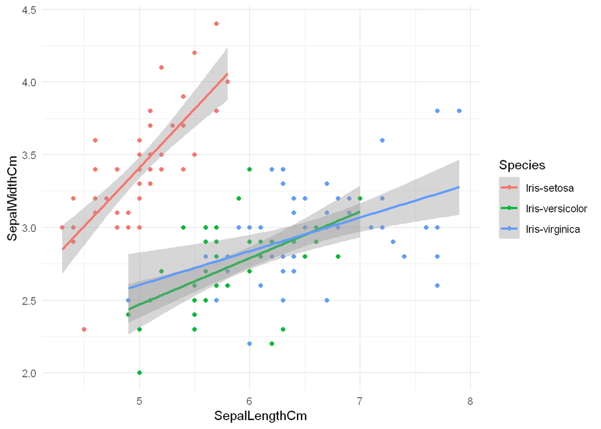

```r
ggplot(data=Iris, aes(x=SepalLengthCm, y=SepalWidthCm, color=Species)) + geom_point() + geom_smooth(method = lm) + theme_minimal()
```

```r
# ggplot(data=Iris, aes(x=SepalLengthCm, y=SepalWidthCm, color=Species)) + geom_point() + geom_smooth(method = lm) + theme_minimal() + sm_statCorr()
```

## make the boxplot for Petal.Width with 3 species separately in the x-axis in different colors

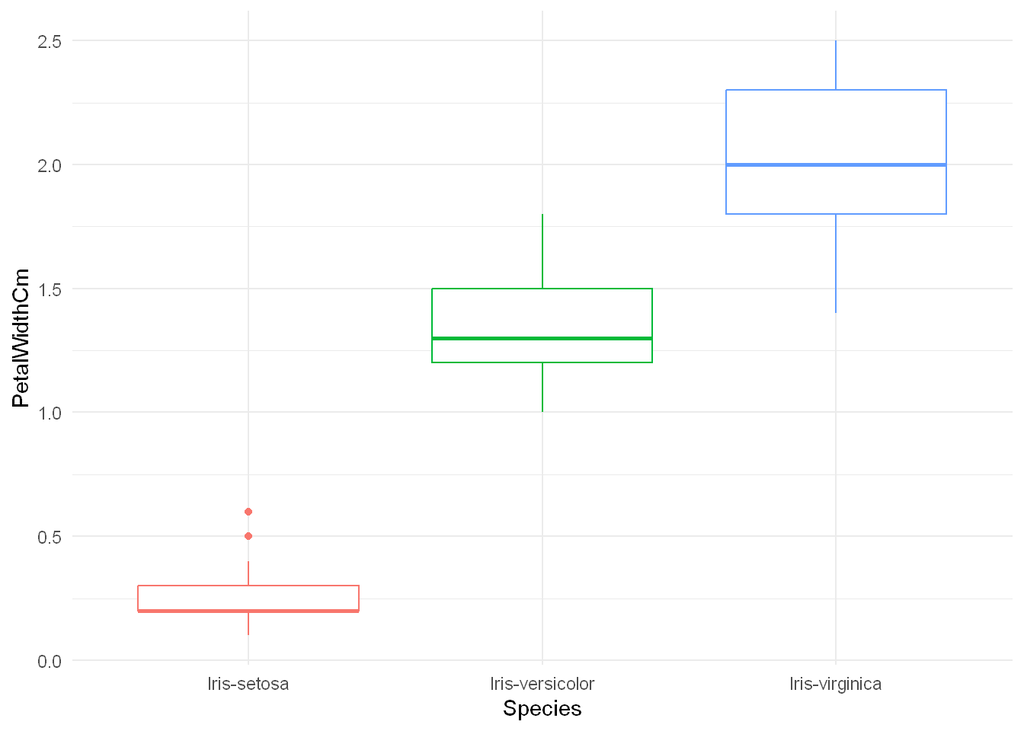

```r
options(repr.plot.width = 5, repr.plot.height = 4)

ggplot(data=Iris, aes(x=Species, y=PetalWidthCm, color=Species)) + geom_boxplot() + theme_minimal() + theme(legend.position="none")
```

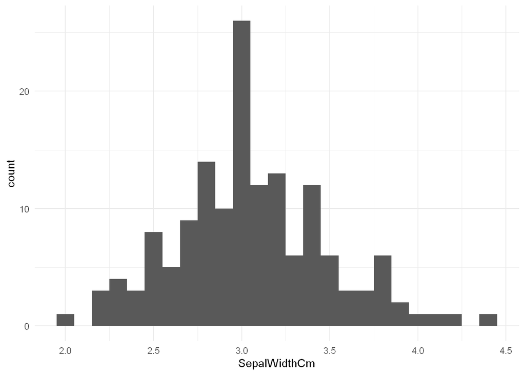

```r
ggplot(data=Iris,aes(x=SepalWidthCm)) + geom_histogram(binwidth=0.1) +theme_minimal()
```

## run the t-test of Petal.Width between setosa and virginica, and give the conclusion if the width is a statistically significant difference between 2 species

```r
# Subsets aufbauen, mit Filterung nach den Species-Bezeichnungen
Setosa <- subset(Iris, Species == "Iris-setosa")
Virginica <- subset(Iris, Species == "Iris-virginica")

# test ausführen
t.test(Setosa$PetalWidthCm, Virginica$PetalWidthCm)
```

```
##
##  Welch Two Sample t-test
##
## data:  Setosa$PetalWidthCm and Virginica$PetalWidthCm
## t = -42.738, df = 63.594, p-value < 2.2e-16
## alternative hypothesis: true difference in means is not equal to 0
## 95 percent confidence interval:
##  -1.865307 -1.698693
## sample estimates:
## mean of x mean of y
##     0.244     2.026
```